# Advanced Machine Learning Final project Presentation

Tran Le

12/02/2020

# Introduction

- The project is about using and compare suppervised Machine Learning method to recognize USPS digit.

## Data

- The data are downloaded from https://www.kaggle.com/bistaumanga/usps-dataset
- The dataset has 7291 train and 2007 test images. The images are 16*16 grayscale pixels
- We use the USPS data, a database of scanned images of handwritten digits from US Postal Services envelopes. These handwritten digits were stretched in a rectangular box 16x16 in a gray scale of 256 values. Then each pixel of each image was scaled into a number from -1 to 1

[figure not shown]

Fig1: A figure in the data

## Goal of the project

- The goal is to recognize digits given their 16x16 pixels
- Apply ML methods to full data and data gotten using PCA for dimention reduction. Compare the accuracy and time run of those methods.

# Detail of the project, the outline

- Investigating the PCA applied to the data set
- Apply ML to full and dimension reduction data

## First, Investigating the PCA applied to the data set

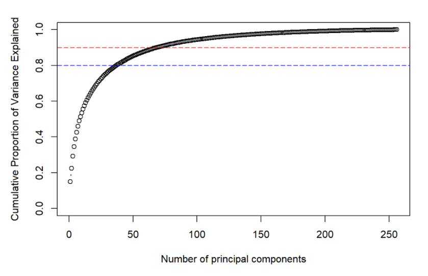

Fig2: Number of PCs vs cummulative proportion of variance explained

- We will chose to create 2 dimention reduction data:
  - The first one uses 81 PCs that explains higher than 90% of the variance.
  - The first one uses 64 PCs that explains higher than 80% of the variance.

## Second, apply ML to full and dimension reduction data:

- This is a supervised problem, we can use these methods to classify the 10 groups:
  - k nearest neighbors
  - Classification tree
  - Random Forest
  - Support Vector Machine
  - Neural network
- Each of the method will be applied before and after applied PCA to compare the accuracy and also the time needed to run for the full data and dimension reducted data .
- The way applying:
  - Fit the model using training set.
  - Evaluate the accuracy on the test set.

# Detail of how to run each methods and the results:

## K nearest neighbors:

- Apply knn with k in $\{1, ..., 10\}$. Choose the one with highest testing accuracy.

[output not shown]

## Classification tree

- Run the rpart to build tree on the training set, then prune the tree, using the cost parameter that minimize the lost function. Use this tree to measure the accuracy on the test set.

| Model_name | Accuracy_full | Runing_time_full | Accuracy_PCA81 | Run_time_PCA81 | Accuracy_PCA64 | Run_time_PCA64 |
| --- | --- | --- | --- | --- | --- | --- |
| rpart | 0.7249626 | 4.64187 secs | 0.7229461 | 3.357013 secs | 0.7229461 | 2.732178 secs |

## Random Forest:

- Run random forest with default arguments

| Model_name | Accuracy_full | Runing_time_full | Accuracy_PCA81 | Run_time_PCA81 | Accuracy_PCA64 | Run_time_PCA64 |
| --- | --- | --- | --- | --- | --- | --- |
| RandomForest | 0.9407075 | 1.536948 mins | 0.2705531 | 22.28762 secs | 0.245142 | 8.512539 secs |

## Support Vector Machine

- Run Support Vector Machine with default arguments

| Model_name | Accuracy_full | Runing_time_full | Accuracy_PCA81 | Run_time_PCA81 | Accuracy_PCA64 | Run_time_PCA64 |
| --- | --- | --- | --- | --- | --- | --- |
| SVM | 0.941704 | 35.33119 secs | 0.1908321 | 14.17465 secs | 0.1908321 | 12.27648 secs |

## Neural network:

- Run the neural network with one hidden layer.
  - For the input layer, the full data give 256 nodes, the PCA81 gives 81 nodes and the PC64 gives 64 nodes.
  - The hidden layer will keep 90% the number of nodes of the input layer.
  - The output layer has 10 nodes.

| Model_name | Accuracy_full | Runing_time_full | Accuracy_PCA81 | Run_time_PCA81 | Accuracy_PCA64 | Run_time_PCA64 |
| --- | --- | --- | --- | --- | --- | --- |
| NeuralNetwork | 0.9367215 | 17.57725 secs | 0.1923269 | 1.729314 secs | 0.1788739 | 1.759174 secs |

# Summarize the results and observation

|  | Model_name | Accuracy_full | Runing_time_full | Accuracy_PCA81 | Run_time_PCA81 | Accuracy_PCA64 | Run_time_PCA64 |
| --- | --- | --- | --- | --- | --- | --- | --- |
| 1 | knn | 0.9367215 | 20.21794 secs | 0.1913303 | 3.272247 secs | 0.1893373 | 0.1878426 secs |
| 2 | rpart | 0.7249626 | 4.64187 secs | 0.7229461 | 3.357013 secs | 0.7229461 | 2.732178 secs |
| 3 | RandomForest | 0.9407075 | 1.536948 mins | 0.2705531 | 22.28762 secs | 0.245142 | 8.512539 secs |
| 4 | SVM | 0.941704 | 35.33119 secs | 0.1908321 | 14.17465 secs | 0.1908321 | 12.27648 secs |
| 5 | NeuralNetwork | 0.9367215 | 17.57725 secs | 0.1923269 | 1.729314 secs | 0.1788739 | 1.759174 secs |

# Limitation and future development:

- Many of the methods uses default arguments. Some more modification can be applied to improve the accuracy.
- The accuracy on the training set can be compute to analyize the properties of each method.
- The number of hidden layers in the neural network and the proportion of nodes keep in each hidden layer can be changed to improve the accuracy